# PSYC2020L Assignment 8

[name]

2025-10-10

## Goals for Review:

- Importing
- NHST

## Setting Up

### 1) Rename this assignment as “Lab 8 Assignment [Last, First].Rmd”

### 2) Check and set (if needed) your working directory. If you’d like to load packages with `library()`, please do so in this block. Make sure to load the `tidyverse` package!

```r
library(tidyverse)
here::here()
```

```
## [1] "C:/Users/jhelmer3/OneDrive - Georgia Institute of Technology/Courses/GTA/PSYC2020L"
```

## Import

### 3) Download the `testdata.csv` file from Canvas, and relocate it to the folder for this lab. Import the csv into R. Try knitting the document right after this question for simpler troubleshooting! This data contains three variables:

| name | description | notes |
| --- | --- | --- |
| `id` | examinee identifier |  |
| `SAT` | SAT score | can theoretically range 400–1600 |
| `ACT` | ACT score | can theoretically range 1–36 |

Display the first few rows of this data.

```r
dat <- rio::import(here::here("labs", "Lab 8 - NHST II", "testdata.csv"))
head(dat)
```

```
##   id  SAT ACT
## 1  1 1000  24
## 2  2 1100  35
## 3  3  950  21
## 4  4 1070  26
## 5  5 1150  31
## 6  6 1280  28
```

## EDA

### 4) Explore or report on the SAT variable in three different ways. Examples include making a plot, commenting on the shape of the distribution, numerical summary statistics (e.g, mean, SD, range), etc.

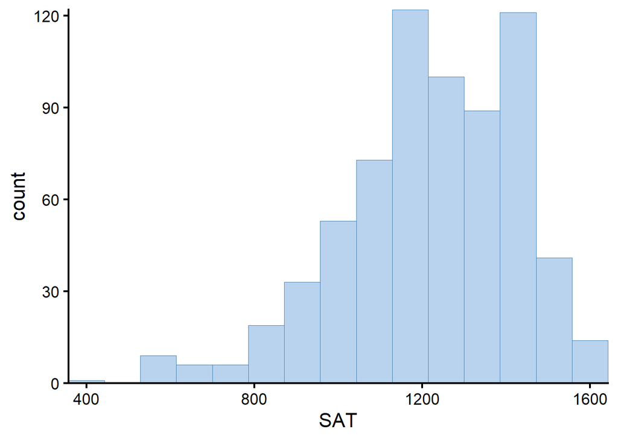

```r
ggplot(dat, aes(x = SAT)) +
  geom_histogram(bins = 15, fill = "slategray2", color = "steelblue", linewidth = .2) +
  coord_cartesian(expand = F) +
  theme_classic(base_size = 16)
```

```r
range(dat$SAT, na.rm = T)
```

```
## [1]  400 1600
```

```r
mean(dat$SAT, na.rm = T)
```

```
## [1] 1222.552
```

### 4) Explore or report on the ACT variable in three different ways. Examples include making a plot, commenting on the shape of the distribution, numerical summary statistics (e.g, mean, SD, range), etc.

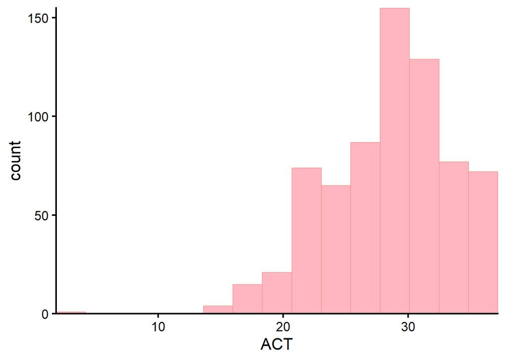

```r
ggplot(dat, aes(x = ACT)) +
  geom_histogram(bins = 15, fill = "lightpink", color = "salmon", linewidth = .2) +
  coord_cartesian(expand = F) +
  theme_classic(base_size = 16)
```

```r
range(dat$ACT)
```

```
## [1]  3 36
```

```r
mean(dat$ACT)
```

```
## [1] 28.54714
```

## *Z*-Tests

You’ve been tasked with testing whether the scores from this sample of students differ from the population means.

### 5a) Let’s say the population mean for SAT scores is 1200 and the population SD is 110. What are your null and alternative hypotheses?

The null hypothesis is that the observed mean of SAT scores is equal to the hypothesized population mean of 1200. The alternative is that the observed mean of SAT scores is not equal to the hypothesized population mean of 1200.

### 5b) Calculate the *z*-test statistic for this sample of SAT scores against the population.

```r
(mean(dat$SAT, na.rm = T) - 1200) / (110 / sqrt(sum(!is.na(dat$SAT))))
```

```
## [1] 5.373589
```

```r
(mean(dat$SAT, na.rm = T) - 1200) / (110 / length(dat$SAT)) # ideally they do the top one but this is finee
```

```
## [1] 143.5107
```

### 5c) What is the *p*-value of that *z*-statistic?

```r
pnorm((mean(dat$SAT, na.rm = T) - 1200) / (110 / sqrt(sum(!is.na(dat$SAT)))), lower.tail = F)
```

```
## [1] 3.859228e-08
```

```r
pnorm((mean(dat$SAT, na.rm = T) - 1200) / (110 / length(dat$SAT)), lower.tail = F) # for if they do the top one
```

```
## [1] 0
```

### 5d) Provide an interpretation for this *z*-test given the test statistic and *p*-value.

We reject the null hypothesis. There is a significant difference between the observed sample mean and the population mean.

```r
(mean(dat$ACT, na.rm = T) - 29) / (sqrt(64) / sqrt(sum(!is.na(dat$ACT))))
```

```
## [1] -1.497684
```

```r
(mean(dat$ACT, na.rm = T) - 29) / (sqrt(64) / length(dat$ACT)) # is fineeeeee
```

```
## [1] -39.625
```

### 6c) What is the *p*-value of that *z*-statistic?

```r
pnorm((mean(dat$ACT, na.rm = T) - 29) / (sqrt(64) / sqrt(sum(!is.na(dat$ACT)))))
```

```
## [1] 0.06710766
```

```r
pnorm((mean(dat$ACT, na.rm = T) - 29) / (sqrt(64) / length(dat$ACT))) # okayyyy if use the length() function before
```

```
## [1] 0
```

### 6d) Provide an interpretation for this *z*-test given the test statistic and *p*-value.

We retain the null hypothesis. In this sample we do not see a significant difference between the observed sample mean and the population mean of ACT scores.